# Focusing on Possession: All subsections of 21a-279

Andrew Ba Tran

June 5, 2015

21a-279(d) is notable out of all the other possession charges in that it carries a minimum sentence of two years if charged. It’s up to police to determine whether or not to charge a suspect with it but prosecutors might offer a plea deal to a subsection of the statute that does not have a minimum sentence.

The court does not track at an aggregate level whether a charges were swapped out for lesser versions.

This analysis looks at the percent of **arrests** and with all subsections of statute 21a-279 and compares it to the **convictions** of the same subsections to see if the ratio changes significantly between.

#### Before we start, it should be noted that the arrests data set has 354951 observations and the convictions has a much lesser amount with 92865 because it does not count cases that were dismissed or found not guilty.

#### What’s the race breakdown for all Possession arrests and convictions?

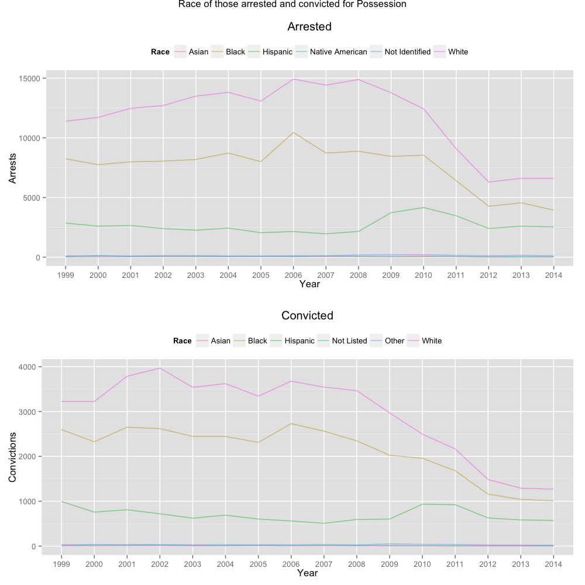

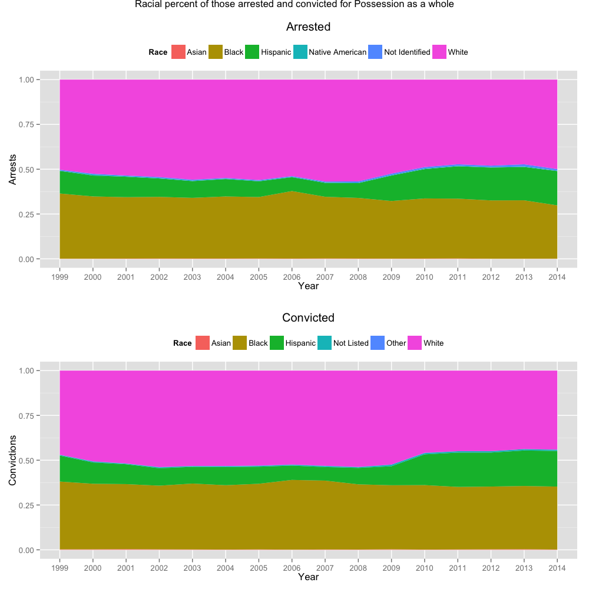

#### How has the arrest charges changed over time?

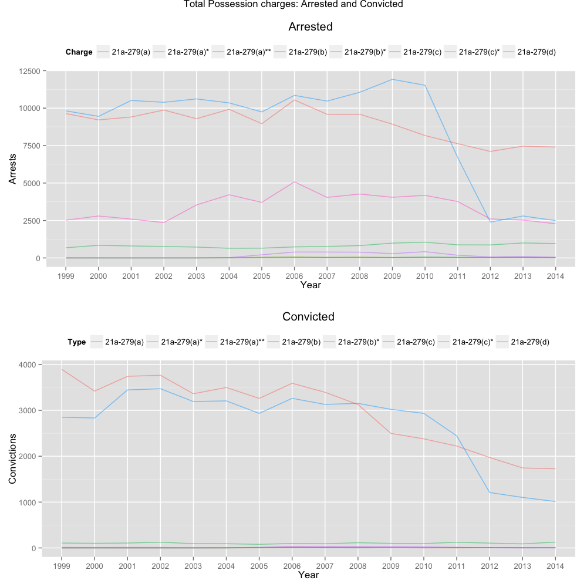

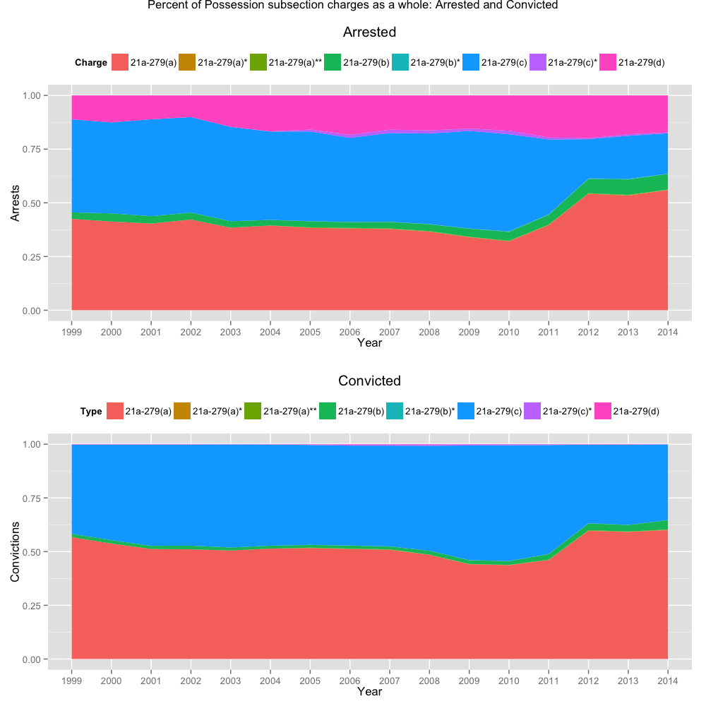

#### All the subcharges of statute 21a-279 as a percent of total arrests and total convictions

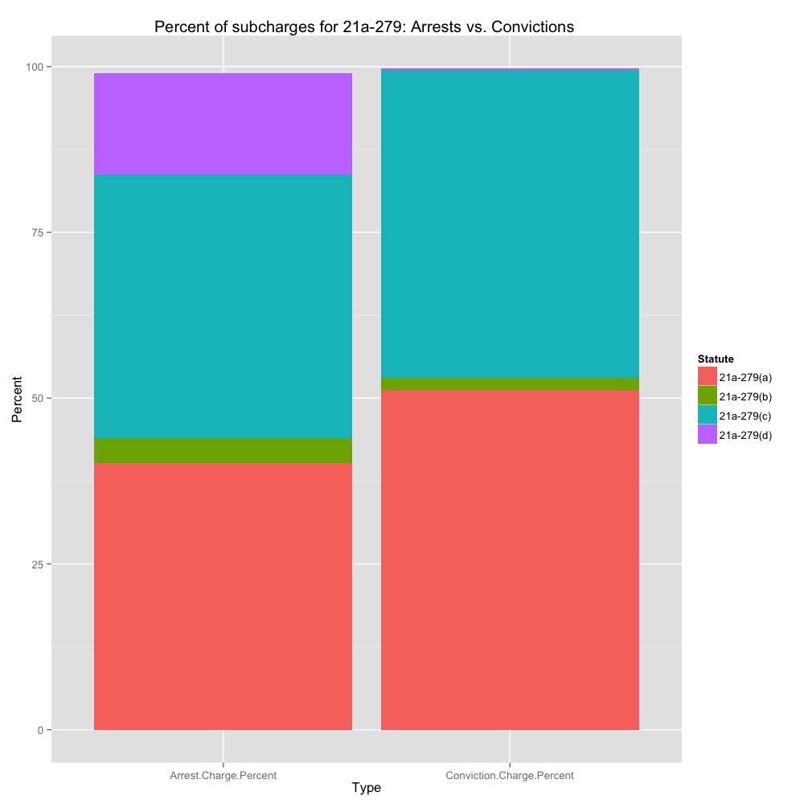

You can see how the rate of **arrests** for Possession in a school zone (15.36)% is much higher than the rate of **convictions** at (0.14)%.

### Let’s look at the breakdown between urban and suburban towns

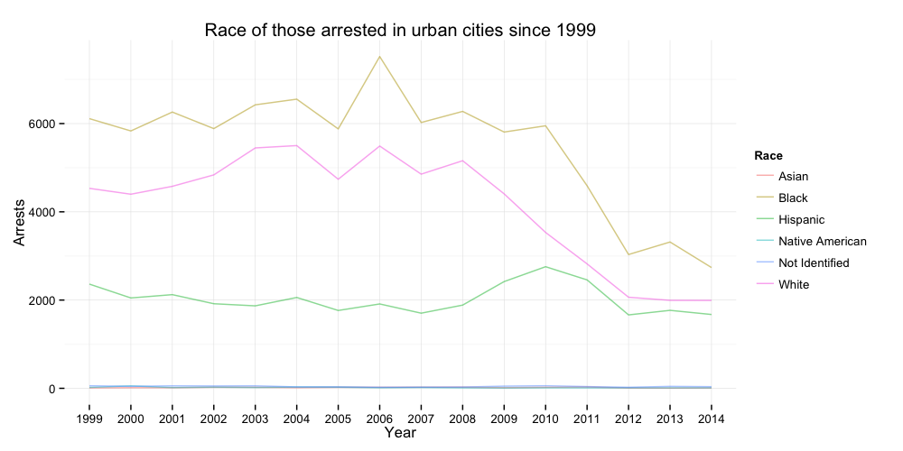

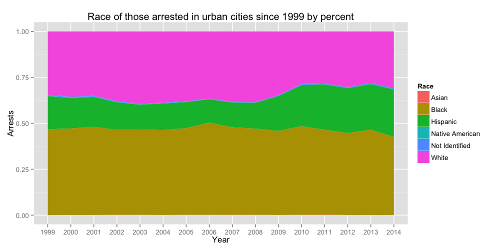

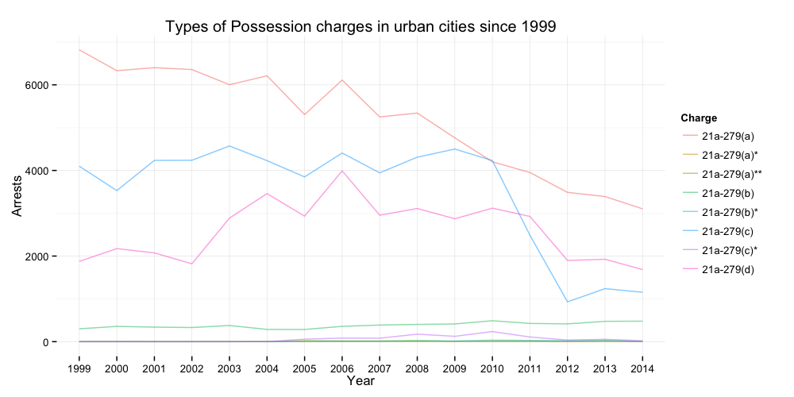

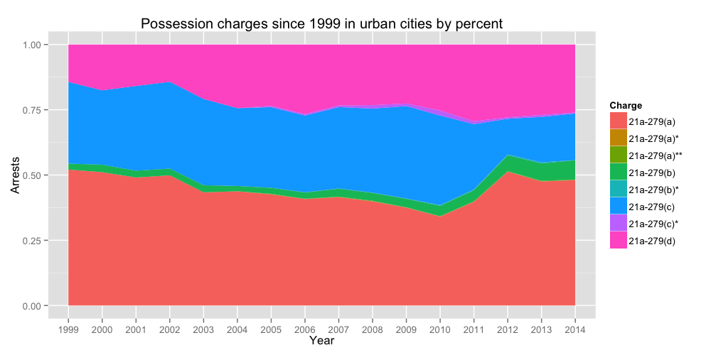

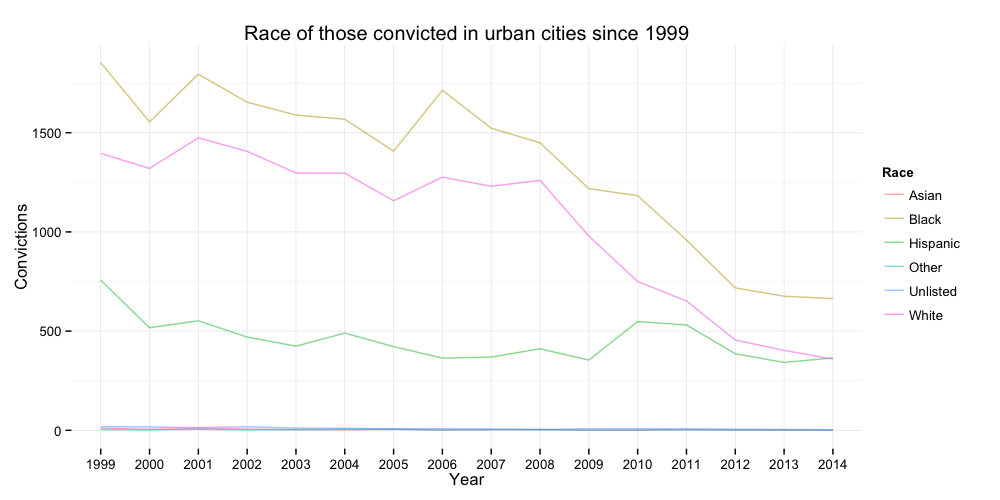

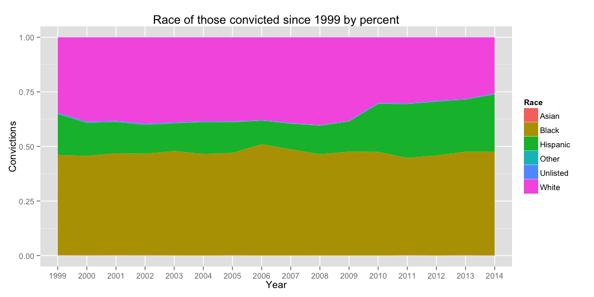

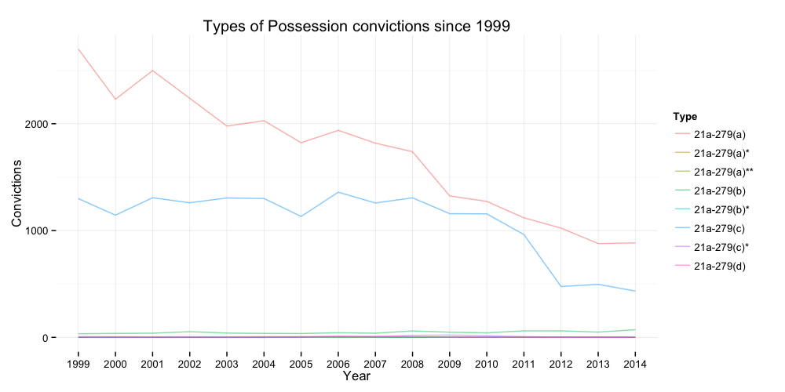

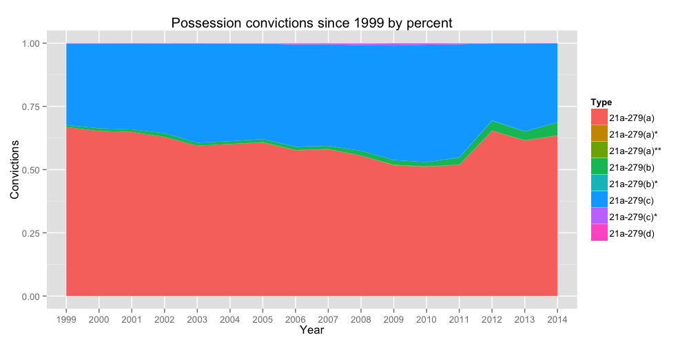

[figure not shown]

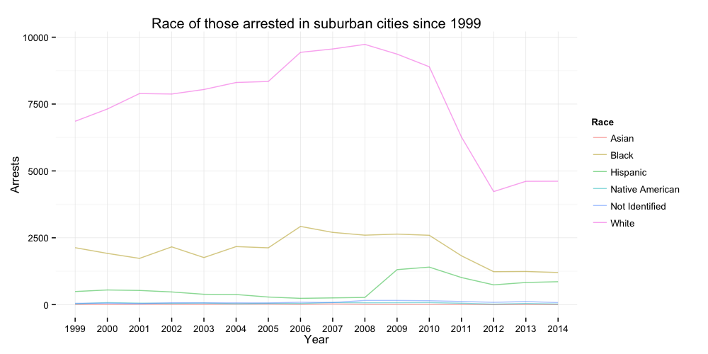

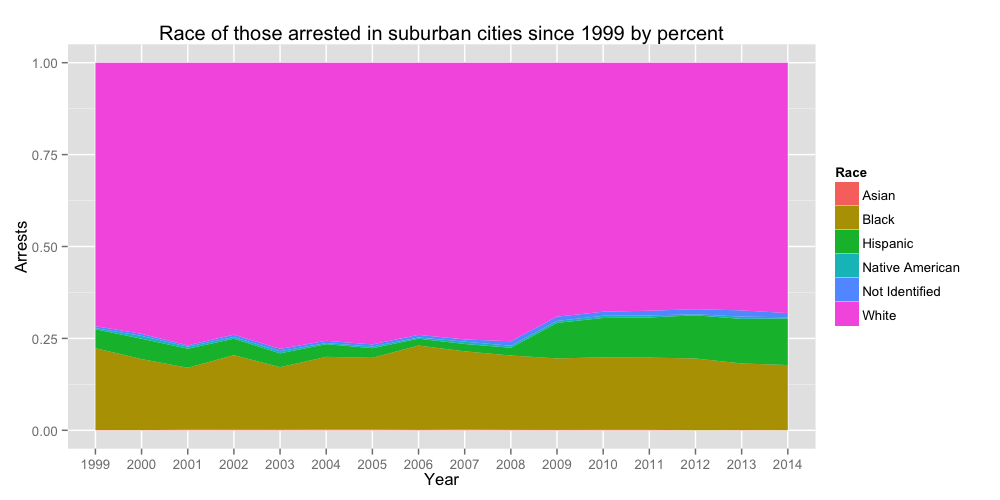

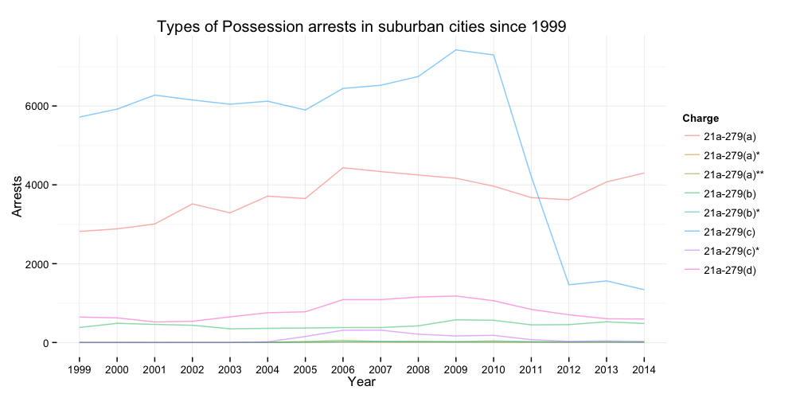

[6 more figures not shown]